# Goodbye to Harder House

Author

Affiliation

[Ted Laderas](https://laderast.github.io)

[Fred Hutch](https://fredhutch.org)

Published

July 28, 2023

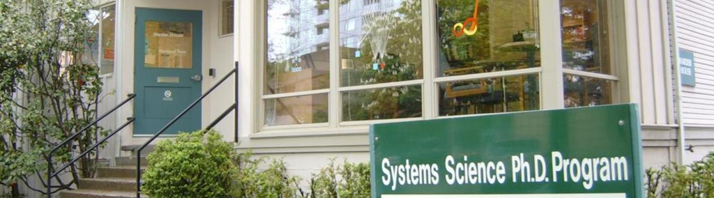

```r
#! echo: false
knitr::include_graphics("sysc_1_3.jpeg")
```

i was driving by the Portland State University campus and discovered to my shock that Harder House was no more.

Harder House was a run down Victorian house that housed the [Systems Science program](https://www.pdx.edu/systems-science/). I took a number of courses in the program, including courses in Systems Theory and different modeling methods. The largest room, where classes were mostly held, was probably no larger that 15 feet by 15 feet, and we were crammed in there in a very tight square of tables.

Sure it was run down, but we always thought it fit the Systems Science program, and it made us feel like the underdogs. I spent countless hours in that room, having wonderful conversations with students of so many backhrounds.

My time there was intertwined with reading many of the classics of systems science: [Herbert Simon](https://en.wikipedia.org/wiki/The_Sciences_of_the_Artificial), [information theory](https://www.nowpublishers.com/article/BookDetails/9781638281146), network theory, [System Dynamics and differential equations](https://www.amazon.com/Business-Dynamics-Systems-Thinking-Modeling/dp/007238915X), queue theory, among others. Conversations with other students in the courses was always super productive. And fascinating, because you were equally likely to talk with marketing folks, economists, and biologists. All different walks of life.

I’ve often said that the strength of systems science is it’s treatment of relationships and interactions, of understanding these relationships holistically [^1]. In fact, I gave a talk for their weekly seminar called [“How Are Data Science and System Science connected?”](https://pdxscholar.library.pdx.edu/systems_science_seminar_series/81/) where I talked about how systems science can improve feature engineering in machine learning.

It might seem very abstract from the outside, but systems science is concerned with real world phenomena. I learned how to read and understand the flow of systems of differential equations by building models and perturbing them. I learned the importance of feedback and how it can push a system into different states. I learned about information theory and [reconstructability analysis](https://pdxscholar.library.pdx.edu/sysc_fac/125/) and how you can use it to untangle systems based on outputs and inputs. I learned about networks and hierarchies and tested some of the ideas on biological systems.

The [Systems Science Program](https://www.pdx.edu/systems-science/) lives on, and Harder House was just a place, but I thought I’d talk a little bit about the history of it and acknowledge my own debt to the program; it has made me a much more well rounded thinker and always looking for the metaphoric connections between different fields.

## Footnotes

[^1]: Marty Zwick has finished his book on Systems Philosophy called [*Elements and Relations: Aspects of a Scientific Metaphysics*](https://link.springer.com/book/10.1007/978-3-030-99403-7) - it is a dense book but full of great ideas.